# Case Study 1

#### Introduction:

The Hoppy Specter Brewery is looking to expand into a new U.S. State with their world-renowned heavily hopped “Pale as a Ghost” pale ale. Given the overwhelming bitterness of both their ethos and beer, they need to find the best home for their new location. They’ve asked Unique Consulting Svcs., LLC. to help them identify the new location.

#### Question 1

Given the big increase in local breweries over the last several years we decided to take a look at the number of breweries in each state. While we would not recomend opening in an overly saturated market, we still think a place that has an established local brewery scene would be best. We wrote some code that helps us to identify the number of breweries present in each state.

```r
brew_count <- count(Breweries$State)
colnames(brew_count) <- c("State", "Brewery_Count")
brew_count <- brew_count[with(brew_count,order(-Brewery_Count)), ]
# head(brew_count, 10)
knitr::kable(brew_count)
```

|  | State | Brewery_Count |
| --- | --- | --- |
| 6 | CO | 47 |
| 5 | CA | 39 |
| 23 | MI | 32 |
| 38 | OR | 29 |
| 44 | TX | 28 |
| 39 | PA | 25 |
| 20 | MA | 23 |
| 48 | WA | 23 |
| 16 | IN | 22 |
| 49 | WI | 20 |
| 28 | NC | 19 |
| 15 | IL | 18 |
| 35 | NY | 16 |
| 46 | VA | 16 |
| 10 | FL | 15 |
| 36 | OH | 15 |
| 24 | MN | 12 |
| 4 | AZ | 11 |
| 47 | VT | 10 |
| 22 | ME | 9 |
| 25 | MO | 9 |
| 27 | MT | 9 |
| 7 | CT | 8 |
| 1 | AK | 7 |
| 11 | GA | 7 |
| 21 | MD | 7 |
| 37 | OK | 6 |
| 13 | IA | 5 |
| 14 | ID | 5 |
| 19 | LA | 5 |
| 30 | NE | 5 |
| 40 | RI | 5 |
| 12 | HI | 4 |
| 18 | KY | 4 |
| 33 | NM | 4 |
| 41 | SC | 4 |
| 45 | UT | 4 |
| 51 | WY | 4 |
| 2 | AL | 3 |
| 17 | KS | 3 |
| 31 | NH | 3 |
| 32 | NJ | 3 |
| 43 | TN | 3 |
| 3 | AR | 2 |
| 9 | DE | 2 |
| 26 | MS | 2 |
| 34 | NV | 2 |
| 8 | DC | 1 |
| 29 | ND | 1 |
| 42 | SD | 1 |
| 50 | WV | 1 |

As we can see from the above, Colorado’s market is likely saturated. States like Pennsylvania, Massachussets, Washington or Indiana might be more ripe for new opportunities.

#### Preparing the data for deeper analysis:

In order to provide the best possible data for our customer, Unique Consulting drew upon multiple data sets to best inform their decision making. Unfortunately, this data required some work to put in a proper form to support analysis. No billable hours were spent on these tasks. Tasks included:

1. Merging the data sets into a single data set capable of allowing comparisons needed.

```r
# Merge the two dataframes

MergedBrewing = merge(Beers,Breweries, by = "Brewery_id")

# Fix the names conflict

names(MergedBrewing)[2] = "Beer_Name"
names(MergedBrewing)[8] = "Brewery_Name"
head(MergedBrewing)
```

```
##   Brewery_id     Beer_Name Beer_ID   ABV IBU
## 1          1  Get Together    2692 0.045  50
## 2          1 Maggie's Leap    2691 0.049  26
## 3          1    Wall's End    2690 0.048  19
## 4          1       Pumpion    2689 0.060  38
## 5          1    Stronghold    2688 0.060  25
## 6          1   Parapet ESB    2687 0.056  47
##                                 Style Ounces       Brewery_Name
## 1                        American IPA     16 NorthGate Brewing
## 2                  Milk / Sweet Stout     16 NorthGate Brewing
## 3                   English Brown Ale     16 NorthGate Brewing
## 4                         Pumpkin Ale     16 NorthGate Brewing
## 5                     American Porter     16 NorthGate Brewing
## 6 Extra Special / Strong Bitter (ESB)     16 NorthGate Brewing
##          City State
## 1 Minneapolis    MN
## 2 Minneapolis    MN
## 3 Minneapolis    MN
## 4 Minneapolis    MN
## 5 Minneapolis    MN
## 6 Minneapolis    MN
```

As an example, here are the first 6 rows:

```r
knitr::kable(head(MergedBrewing,6))
```

| Brewery_id | Beer_Name | Beer_ID | ABV | IBU | Style | Ounces | Brewery_Name | City | State |
| --- | --- | --- | --- | --- | --- | --- | --- | --- | --- |
| 1 | Get Together | 2692 | 0.045 | 50 | American IPA | 16 | NorthGate Brewing | Minneapolis | MN |
| 1 | Maggie’s Leap | 2691 | 0.049 | 26 | Milk / Sweet Stout | 16 | NorthGate Brewing | Minneapolis | MN |
| 1 | Wall’s End | 2690 | 0.048 | 19 | English Brown Ale | 16 | NorthGate Brewing | Minneapolis | MN |
| 1 | Pumpion | 2689 | 0.060 | 38 | Pumpkin Ale | 16 | NorthGate Brewing | Minneapolis | MN |
| 1 | Stronghold | 2688 | 0.060 | 25 | American Porter | 16 | NorthGate Brewing | Minneapolis | MN |
| 1 | Parapet ESB | 2687 | 0.056 | 47 | Extra Special / Strong Bitter (ESB) | 16 | NorthGate Brewing | Minneapolis | MN |

and the last 6 rows:

```r
knitr::kable(tail(MergedBrewing,6))
```

|  | Brewery_id | Beer_Name | Beer_ID | ABV | IBU | Style | Ounces | Brewery_Name | City | State |
| --- | --- | --- | --- | --- | --- | --- | --- | --- | --- | --- |
| 2405 | 556 | Pilsner Ukiah | 98 | 0.055 | NA | German Pilsener | 12 | Ukiah Brewing Company | Ukiah | CA |
| 2406 | 557 | Heinnieweisse Weissebier | 52 | 0.049 | NA | Hefeweizen | 12 | Butternuts Beer and Ale | Garrattsville | NY |
| 2407 | 557 | Snapperhead IPA | 51 | 0.068 | NA | American IPA | 12 | Butternuts Beer and Ale | Garrattsville | NY |
| 2408 | 557 | Moo Thunder Stout | 50 | 0.049 | NA | Milk / Sweet Stout | 12 | Butternuts Beer and Ale | Garrattsville | NY |
| 2409 | 557 | Porkslap Pale Ale | 49 | 0.043 | NA | American Pale Ale (APA) | 12 | Butternuts Beer and Ale | Garrattsville | NY |
| 2410 | 558 | Urban Wilderness Pale Ale | 30 | 0.049 | NA | English Pale Ale | 12 | Sleeping Lady Brewing Company | Anchorage | AK |

2. In order to prepare for this analysis, we also needed to identify the number of values missing in the data set. We found the following results:

```r
knitr::kable(colSums(is.na(MergedBrewing)))
```

|  | x |
| --- | --- |
| Brewery_id | 0 |
| Beer_Name | 0 |
| Beer_ID | 0 |
| ABV | 62 |
| IBU | 1005 |
| Style | 0 |
| Ounces | 0 |
| Brewery_Name | 0 |
| City | 0 |
| State | 0 |

At some points in the analysis below, the missing values are not considered. We’ve identified those areas of concern below.

#### The market for “Pale as a Ghost” Pale Ale:

The “Pale as a Ghost” pale ale is the flagship beer for The Hoppy Specter Brewery and it scores high in ABV (alchol by volume) and IBU (bitterness). We would like to get a broad overview of the general taste trends for each state when it comes to ABV and IBU. The plots below show the median ABV and IBU for each state.

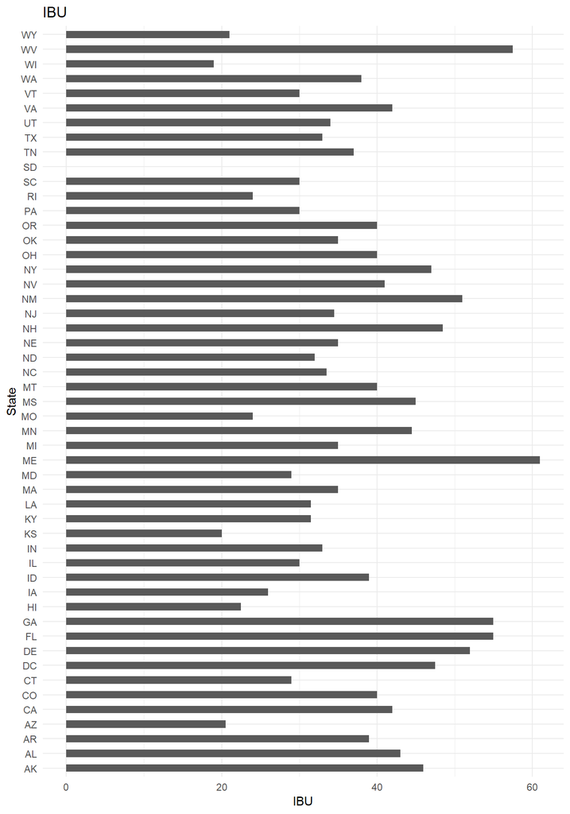

```r
#Get Medians
state_ibu_medians <- tapply(MergedBrewing$IBU, MergedBrewing$State, median, na.rm = T)
state_ibu_medians <- data.frame(state_ibu_medians)

#Reset Column Names
setDT(state_ibu_medians , keep.rownames = TRUE)
colnames(state_ibu_medians) <- c("State", "IBU_Medians")

#Bar Plot
p <- ggplot(data = state_ibu_medians, aes(x=State, y=IBU_Medians, width = .5)) +
    labs(title="IBU", x="State", y = "IBU")

p + geom_bar(stat="identity") +
    theme(plot.title = element_text(hjust = 0.5), legend.position = "none") +
    coord_flip() +
    theme_minimal()
```

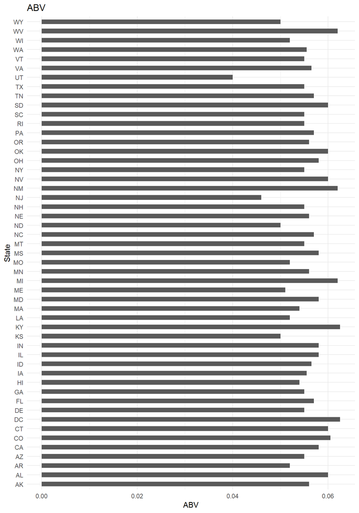

```r
#ABV Medians
state_abv_medians <- tapply(MergedBrewing$ABV, MergedBrewing$State, median, na.rm = T)
state_abv_medians <- data.frame(state_abv_medians)

#Reset Column Names
setDT(state_abv_medians , keep.rownames = TRUE)
colnames(state_abv_medians) <- c("State", "ABV_Medians")

#Bar Plot
p <- ggplot(data = state_abv_medians, aes(x=State, y=ABV_Medians, width = .5)) +
    labs(title="ABV", x="State", y = "ABV")

p + geom_bar(stat="identity") +
    theme(plot.title = element_text(hjust = 0.5), legend.position = "none") +
    coord_flip() +
    theme_minimal()
```

#### Question 5

Given that our client's beer is very strong and bitter, we would like to study markets with these same specs. The code below returns the states with the highest ABV and IBU.

```r
#State with max ABV
MergedBrewing[which.max(MergedBrewing$ABV), "State"]
```

```
## [1] "CO"
```

```r
#State with max IBU
MergedBrewing[which.max(MergedBrewing$IBU), "State"]
```

```
## [1] "OR"
```

#### Question 6

```r
summary(MergedBrewing$ABV)
```

```
##    Min. 1st Qu.  Median    Mean 3rd Qu.    Max.    NA's
## 0.00100 0.05000 0.05600 0.05977 0.06700 0.12800      62
```

#### Question 7

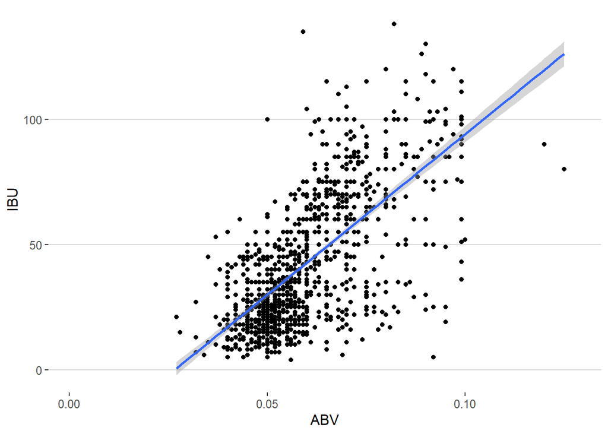

```r
p <- ggplot(MergedBrewing, aes(x=ABV, y=IBU)) + geom_point(shape=16) +  geom_smooth(method=lm)
p + theme_hc()+ scale_colour_hc()
```